# Imputation of Data with Non-linear Associations

## Preface

### R packages

In this practical, a number of R packages are used. If any of them are not installed you may be able to follow the practical but will not be able to run all of the code. The packages used (with versions that were used to generate the solutions) are:

- R version 4.0.0 (2020-04-24)
- `mice` (version: 3.8.0)
- `JointAI` (version: 0.6.1)
- `ggplot2` (version: 3.3.0)
- `reshape2` (version: 1.4.4)
- `ggpubr` (version: 0.2.5)

### Help files

You can find help files for any function by adding a `?` before the name of the function.

Alternatively, you can look up the help pages online at https://www.rdocumentation.org/ or find the whole manual for a package at https://cran.r-project.org/web/packages/available_packages_by_name.html

### Dataset

For this practical, we will use the **EP16dat2** dataset, which is a subset of the [NHANES (National Health and Nutrition Examination Survey)](https://www.cdc.gov/nchs/nhanes/index.htm) data.

To get the **EP16dat2** dataset, load the file `EP16dat2.RData`. You can download it [here](https://nerler.github.io/EP16_Multiple_Imputation/practical/data/index.html).

To load this dataset into R, you can use the command `file.choose()` which opens the explorer and allows you to navigate to the location of the file on your computer.

If you know the path to the file, you can also use `load("<path>/EP16dat2.RData")`.

To give you a head start, here some basic summary of this data:

```r
str(EP16dat2)
```

```
## 'data.frame':    500 obs. of  12 variables:
##  $ wgt   : num  78 78 75.3 90.7 112 ...
##  $ gender: Factor w/ 2 levels "male","female": 1 1 2 1 2 1 2 2 1 1 ...
##  $ bili  : num  1.1 0.7 0.5 0.8 0.6 0.7 1.1 0.8 0.8 0.5 ...
##  $ age   : num  67 39 64 36 33 62 56 63 55 20 ...
##  $ chol  : num  6.13 4.65 4.14 3.47 6.31 4.47 6.41 5.51 7.01 3.75 ...
##  $ HDL   : num  1.09 1.14 1.29 1.37 1.27 0.85 1.81 2.38 2.79 1.03 ...
##  $ hgt   : num  1.75 1.78 1.63 1.93 1.73 ...
##  $ educ  : Ord.factor w/ 5 levels "Less than 9th grade"<..: 5 3 5 4 4 3 4 5 4 2 ...
##  $ race  : Factor w/ 5 levels "Mexican American",..: 5 3 5 3 4 5 4 5 3 3 ...
##  $ SBP   : num  139 103 NaN 115 107 ...
##  $ hypten: Factor w/ 2 levels "no","yes": 2 1 2 2 1 2 NA 1 2 1 ...
##  $ WC    : num  91.6 84.5 91.6 95.4 119.6 ...
```

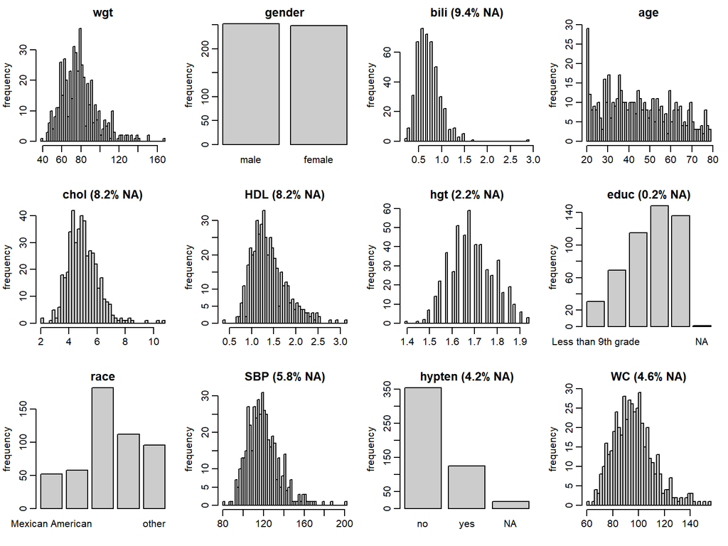

```r
par(mar = c(3, 3, 2, 1), mgp = c(2, 0.6, 0))
JointAI::plot_all(EP16dat2, breaks = 50, nrow = 3)
```

### Aim

The focus of this practical is the imputation of data that has features that require special attention.

In the interest of time, we will focus on these features and **abbreviate steps that are the same as in any imputation setting** (e.g., getting to know the data or checking that imputed values are realistic). **Nevertheless, these steps are of course required when analysing data in practice.**

Our aim is to impute data, so that we can later fit the following linear regression model for weight:

```r
mod <- lm(wgt ~ gender + bili + age * (chol + HDL) + hgt)
```

We expect that the effects of cholesterol and HDL may differ with age, and, hence, include **interaction terms** between `age` and `chol` and `HDL`, respectively.

Additionally, we want to include the other variables in the dataset as auxiliary variables.

## Imputation using **mice**

When the analysis model of interest involves interaction terms between incomplete variables, **mice** has limited options to reduce the bias that may be introduced by naive handling of the missing values.

Use of the “Just Another Variable” approach can in some settings reduce bias. Alternatively, we can use passive imputation, i.e., calculate the interaction terms in each iteration of the MICE algorithm. Furthermore, predictive mean matching tends to lead to less bias than normal imputation models.

### Just Another Variable approach

#### Task 1

- Calculate the interaction terms in the incomplete data.
- Perform the setup-run of `mice()` without any iterations.

#### Solution 1

```r
# calculate the interaction terms
EP16dat2$agechol <- EP16dat2$age * EP16dat2$chol
EP16dat2$ageHDL <- EP16dat2$age * EP16dat2$HDL

# setup run
imp0 <- mice(EP16dat2, maxit = 0,
             defaultMethod = c('norm', 'logreg', 'polyreg', 'polr'))
imp0
```

```
## Class: mids
## Number of multiple imputations:  5
## Imputation methods:
##      wgt   gender     bili      age     chol      HDL      hgt     educ     race      SBP   hypten
##       ""       ""   "norm"       ""   "norm"   "norm"   "norm"   "polr"       ""   "norm" "logreg"
##       WC  agechol   ageHDL
##   "norm"   "norm"   "norm"
## PredictorMatrix:
##        wgt gender bili age chol HDL hgt educ race SBP hypten WC agechol ageHDL
## wgt      0      1    1   1    1   1   1    1    1   1      1  1       1      1
## gender   1      0    1   1    1   1   1    1    1   1      1  1       1      1
## bili     1      1    0   1    1   1   1    1    1   1      1  1       1      1
## age      1      1    1   0    1   1   1    1    1   1      1  1       1      1
## chol     1      1    1   1    0   1   1    1    1   1      1  1       1      1
## HDL      1      1    1   1    1   0   1    1    1   1      1  1       1      1
```

#### Task 2

Apply the necessary changes to the imputation method and predictor matrix.

Since the interaction terms are calculated from the orignal variables, these interaction terms should not be used to impute the original variables.

#### Solution 2

```r
meth <- imp0$method
pred <- imp0$predictorMatrix

# change imputation for "bili" to pmm (to prevent negative values)
meth["bili"] <- 'pmm'

# changes in predictor matrix to prevent feedback from the interactions to the
# original variables
pred["chol", "agechol"] <- 0
pred["HDL", "ageHDL"] <- 0

meth
```

```
##      wgt   gender     bili      age     chol      HDL      hgt     educ     race      SBP   hypten
##       ""       ""    "pmm"       ""   "norm"   "norm"   "norm"   "polr"       ""   "norm" "logreg"
##       WC  agechol   ageHDL
##   "norm"   "norm"   "norm"
```

```r
pred
```

```
##         wgt gender bili age chol HDL hgt educ race SBP hypten WC agechol ageHDL
## wgt       0      1    1   1    1   1   1    1    1   1      1  1       1      1
## gender    1      0    1   1    1   1   1    1    1   1      1  1       1      1
## bili      1      1    0   1    1   1   1    1    1   1      1  1       1      1
## age       1      1    1   0    1   1   1    1    1   1      1  1       1      1
## chol      1      1    1   1    0   1   1    1    1   1      1  1       0      1
## HDL       1      1    1   1    1   0   1    1    1   1      1  1       1      0
## hgt       1      1    1   1    1   1   0    1    1   1      1  1       1      1
## educ      1      1    1   1    1   1   1    0    1   1      1  1       1      1
## race      1      1    1   1    1   1   1    1    0   1      1  1       1      1
## SBP       1      1    1   1    1   1   1    1    1   0      1  1       1      1
## hypten    1      1    1   1    1   1   1    1    1   1      0  1       1      1
## WC        1      1    1   1    1   1   1    1    1   1      1  0       1      1
## agechol   1      1    1   1    1   1   1    1    1   1      1  1       0      1
## ageHDL    1      1    1   1    1   1   1    1    1   1      1  1       1      0
```

Note:

A look at the histogram of `bili` tells us that the variable is not too skewed, but the distribution is relatively close to zero. And in a previous practical we already saw that there were negative values for `bili` when this variable was imputed with a linear regression model.

In practice, I would still try a normal distribution and only use predictive mean matching if the distribution of the imputed values is off.

#### Task 3

Run the imputation using the JAV approach and check the traceplot.

#### Solution 3

```r
# run imputation with the JAV approach
impJAV <- mice(EP16dat2, method = meth, predictorMatrix = pred,
               maxit = 20, printFlag = FALSE, seed = 2020)
```

Note The argument `printFlag` prevents the lengthy output and the argument `seed` can be set to get reproducible results (this sets the seed value for the random number generator).

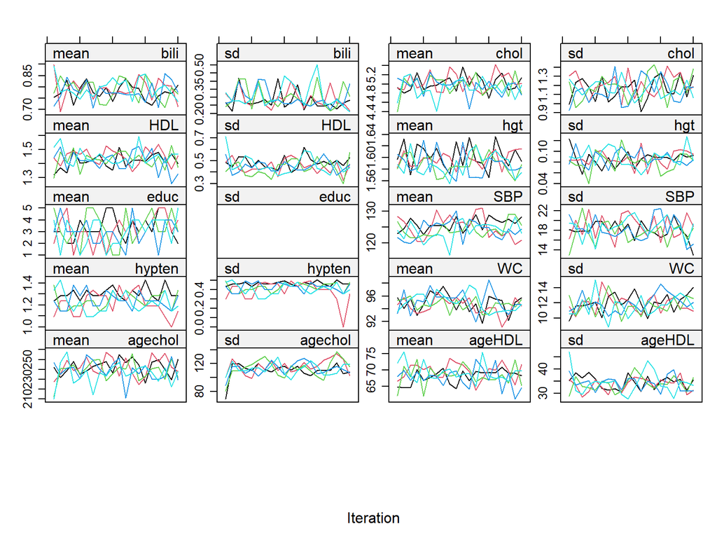

```r
plot(impJAV, layout = c(4, 6))
```

#### Task 4

We skip the more detailed evaluation of the imputed values. With the settings given in the solution the chains have converged and distributions of the imputed values match the distributions of the observed data closely enough.

Analyse the imputed data and pool the results.

#### Solution 4

```r
miraJAV <- with(impJAV,
                lm(wgt  ~ gender + bili + age + chol + HDL + agechol + ageHDL + hgt))
summary(pool(miraJAV), conf.int = TRUE)
```

```
##           term   estimate std.error statistic     df    p.value      2.5 %     97.5 %
## 1  (Intercept) -104.30222 19.760625   -5.2783 328.12 2.3762e-07 -143.17572 -65.428720
## 2 genderfemale    4.34733  1.895943    2.2930 459.69 2.2301e-02    0.62154   8.073116
## 3         bili   -6.51590  2.837362   -2.2965 270.21 2.2415e-02  -12.10204  -0.929748
## 4          age    0.57445  0.230915    2.4877 330.04 1.3349e-02    0.12020   1.028706
## 5         chol    9.09221  2.133174    4.2623 158.57 3.4614e-05    4.87911  13.305310
## 6          HDL  -22.63418  6.257526   -3.6171 223.84 3.6817e-04  -34.96538 -10.302986
## 7      agechol   -0.14096  0.041632   -3.3859 198.91 8.5470e-04   -0.22306  -0.058867
## 8       ageHDL    0.16019  0.128259    1.2490 151.06 2.1360e-01   -0.09322   0.413607
## 9          hgt   99.46239  9.096692   10.9339 460.78 0.0000e+00   81.58624 117.338529
```

### Passive Imputation

For the passive imputation, we can re-use the adjusted versions of `meth` and `pred` we created for the JAV approach, but additional changes to `meth` are necessary.

#### Task 1

Specify the new imputation method, i.e., adapt `meth` and save it as `methPAS`.

For passive imputation, instead of an imputation method you need to specify the formula used to calculate the value that is imputed passively.

#### Solution 1

```r
# changes in imputation method for passive imputation
methPAS <- meth
methPAS[c("agechol", "ageHDL")] <- c("~I(age*chol)", "~I(age*HDL)")
```

#### Task 2

Run the imputation using passive imputation and check the traceplot.

#### Solution 2

```r
# run imputation with passive imputation
impPAS <- mice(EP16dat2, method = methPAS, predictorMatrix = pred,
               maxit = 20, printFlag = FALSE, seed = 2020)
```

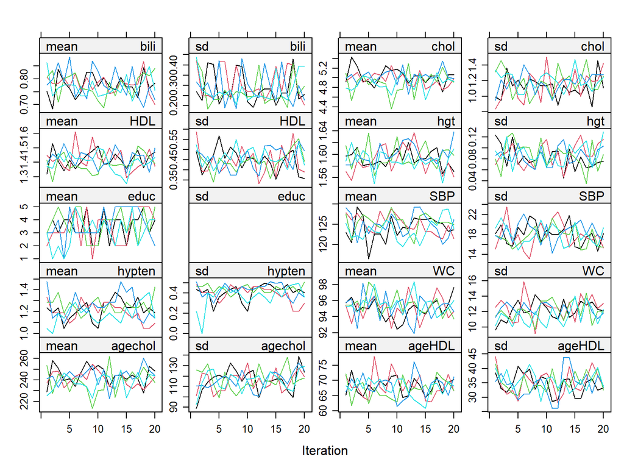

```r
plot(impPAS, layout = c(4, 5))
```

#### Task 3

We will again skip the detailed evaluation of convergence and the imputed values.

Analyse the imputed data and pool the results.

#### Solution 3

```r
miraPAS <- with(impPAS,
                lm(wgt ~ gender + bili + age + chol + HDL + agechol + ageHDL + hgt))

summary(pool(miraPAS), conf.int = TRUE)
```

```
##           term   estimate std.error statistic      df    p.value       2.5 %     97.5 %
## 1  (Intercept) -103.63532 20.120014   -5.1509 264.235 5.0756e-07 -143.251271 -64.019361
## 2 genderfemale    3.78219  1.907669    1.9826 431.464 4.8043e-02    0.032712   7.531674
## 3         bili   -7.41121  2.797252   -2.6495 375.294 8.4028e-03  -12.911464  -1.910960
## 4          age    0.55949  0.240606    2.3254 187.611 2.1122e-02    0.084853   1.034133
## 5         chol    8.83518  2.230626    3.9609 124.145 1.2507e-04    4.420202  13.250166
## 6          HDL  -21.01960  6.510610   -3.2285  95.976 1.7036e-03  -33.943102  -8.096103
## 7      agechol   -0.13400  0.043204   -3.1016 162.749 2.2695e-03   -0.219314  -0.048688
## 8       ageHDL    0.14507  0.134721    1.0768  67.680 2.8537e-01   -0.123781   0.413927
## 9          hgt   99.11277  9.242312   10.7238 386.930 0.0000e+00   80.941332 117.284209
```

## Imputation with **JointAI**

**JointAI** provides functions that allow us to fit Bayesian regression models with incomplete covariates. The main functions are designed to resemble the standard functions to fit regression models with complete data.

For univariate outcomes the following functions are available:

- `lm_imp()`: for linear regression
- `glm_imp()`: for generalized linear regression (e.g., logistic, gamma or Poisson)
- `clm_imp()`: for ordinal (cumulative logit) regression

Note:

There will be a new version of **JointAI** (later this year) which will also provide functions to fit models using a log-normal or a beta distribution, and a function to fit multinomial logit models (for unordered categorical outcomes).

### Specification of the analysis model

Similar to the complete data versions, the functions from **JointAI** take the following arguments:

| `formula` | model formula |
| --- | --- |
| `data` | original, incomplete dataset |
| `family` | for glm’s: the distribution family of the outcome (e.g., `binomial()` for a logistic model) |

#### Task 1

Specify the linear regression model with the model formula given at the beginning of this practical, using `lm_imp()`.

You need to specify the arguments `formula`, `data` and `n.iter`. Set `n.iter = 100` (we will learn more about this argument a little bit later).

#### Solution 1

```r
lm1 <- lm_imp(wgt ~ gender + bili + age * (chol + HDL) + hgt, data = EP16dat2,
              n.iter = 100)
```

```r
lm1
```

```
##
## Call:
## lm_imp(formula = wgt ~ gender + bili + age * (chol + HDL) + hgt,
##     data = EP16dat2, n.iter = 100)
##
##
## Coefficients:
##  (Intercept) genderfemale         bili          age         chol          HDL          hgt
##    -102.6540       3.8934      -6.8168       0.6044       9.2504     -21.6579      97.4204
##     age:chol      age:HDL
##      -0.1459       0.1556
##
##
## Residual standard deviation:
## sigma_wgt
##     15.58
```

#### Task 2

`lm_imp()` returns an object of class `JointAI`, which contains

- the original data (`data`),
- information on the type of model (`call`, `analysis_type`, `models`, `fixed`, `random`, `hyperpars`, `scale_pars`) and
- information about the MCMC sampling (`mcmc_settings`),
- the JAGS model (`model`) and
- the MCMC sample (`MCMC`; if a sample was generated),
- the computational time (`time`) of the MCMC sampling, and
- some additional elements that are used by methods for objects of class `JointAI` but are typically not of interest for the user.

Check which imputation models were used in `lm1`.

The imputation model types are returned in the JointAI object under “models”.

#### Solution 2

```r
lm1$models
```

```
##    hgt   chol    HDL   bili
## "norm" "norm" "norm" "norm"
```

### Specification of the imputation models

In **JointAI**, there are some arguments related to the imputation part of the model:

| `models` | vector of imputation methods (for details see below and the vignette on [Model Specification](https://nerler.github.io/JointAI/articles/ModelSpecification.html#meth)) |
| --- | --- |
| `auxvars` | a formula of variables that are not part of the analysis model but should be used to predict missing values (optional; for details see the vignette on [Model Specification](https://nerler.github.io/Jo… |
| `refcats` | allows specification of which category of categorical variables is used as reference (optional; for details see the vignette on [Model Specification](https://nerler.github.io/JointAI/articles/ModelSpe… |
| `trunc` | allow truncation of distributions of incomplete continuous covariates (for details see the vignette on [Model Specification](https://nerler.github.io/JointAI/articles/ModelSpecification.html#functions… |

Like in **mice** default imputation models are chosen based on the `class` of each of the incomplete variables. The default choices for baseline (not time-varying) covariates are

| name | model | variable type |
| --- | --- | --- |
| `norm` | linear regression | continuous variables |
| `logit` | logistic regression | factors with two levels |
| `multilogit` | multinomial logit model | unordered factors with >2 levels |
| `cumlogit` | cumulative logit model | ordered factors with >2 levels |

Alternative imputation methods are available for continuous baseline covariates:

| name | model | variable type |
| --- | --- | --- |
| `lognorm` | normal regression of the log-transformed variable | right-skewed variables >0 |
| `gamma` | Gamma regression (with log-link) | right-skewed variables >0 |
| `beta` | beta regression (with logit-link) | continuous variables with values in [0, 1] |

#### Task

Re-fit the linear regression model, but now

- specify a log-normal or a gamma distribution for `bili`
- set the reference category to the largest group
- use the other variables that are in the data as auxiliary variables

To specify a non-default imputation method use the argument `models = c(bili = ...)`.

To set the respective largest group as reference category for all categorical variables use the argument `refcats = "largest"`.

Auxiliary variables need to be specified explicitely using the argument `auxvars`. It takes a formula of variable names.

#### Solution

```r
lm2 <- lm_imp(wgt ~ gender + bili + age * (chol + HDL) + hgt, data = EP16dat2,
              auxvars = ~ educ + race + SBP + hypten + WC,
              models = c(bili = 'lognorm'), refcats = 'largest',
              n.iter = 100, seed = 2020)
```

Note:

By default, no output is printed during the adaptive phase. If you want to be sure that the model is running and your computer did not just get stuck you can set the argument `quiet = FALSE`.

### Specification of the MCMC settings

Specification of the basic settings for the MCMC sampling can be done using the following arguments:

| `n.chains` | number of MCMC chains |
| --- | --- |
| `n.adapt` | number of iterations used in the adaptive phase |
| `n.iter` | number of iterations per MCMC chain in the sampling phase |

**JointAI** has more arguments than the ones given above, but in this practical we focus only on the most important. You may find out more about all the arguments in the vignette on [MCMC Settings](https://nerler.github.io/JointAI/articles/MCMCsettings.html).

By default, `n.chains = 3`, `n.adapt = 100` and `n.iter = 0`.

It is useful to use more than one chain to be able to evaluate convergence of the MCMC chains.

Samples in the adaptive phase are not used for the final MCMC sample. They are needed to optimize the MCMC sampler. When the number provided via the argument `n.adapt` is insufficient for this optimization a warning message will be printed. In simple models (e.g., linear regression) usually the default value of `n.adapt = 100` can be used.

The default value for `n.iter`, the number of iterations in the sampling phase is `0` (no MCMC sample will be created). The number of iterations that is needed depends on how complex the model and the data is and can range from somewhere as low as 100 up to several million.

In the following, we will look at some criteria to determine if the number of MCMC samples that was used is sufficient.

### Evaluation of the MCMC sample

The first step after fitting a Bayesian model should be to confirm that the MCMC chains have converged. This can be done visually, using a traceplot (plotting the sampled values per parameter and chain across iterations) or using the Gelman-Rubin criterion.

#### Task 1

Investigate convergence of `lm2` by creating a traceplot using the function `traceplot()`. The plot should show a horizontal band without trends or patterns and the different chains should be mixed.

#### Solution 1

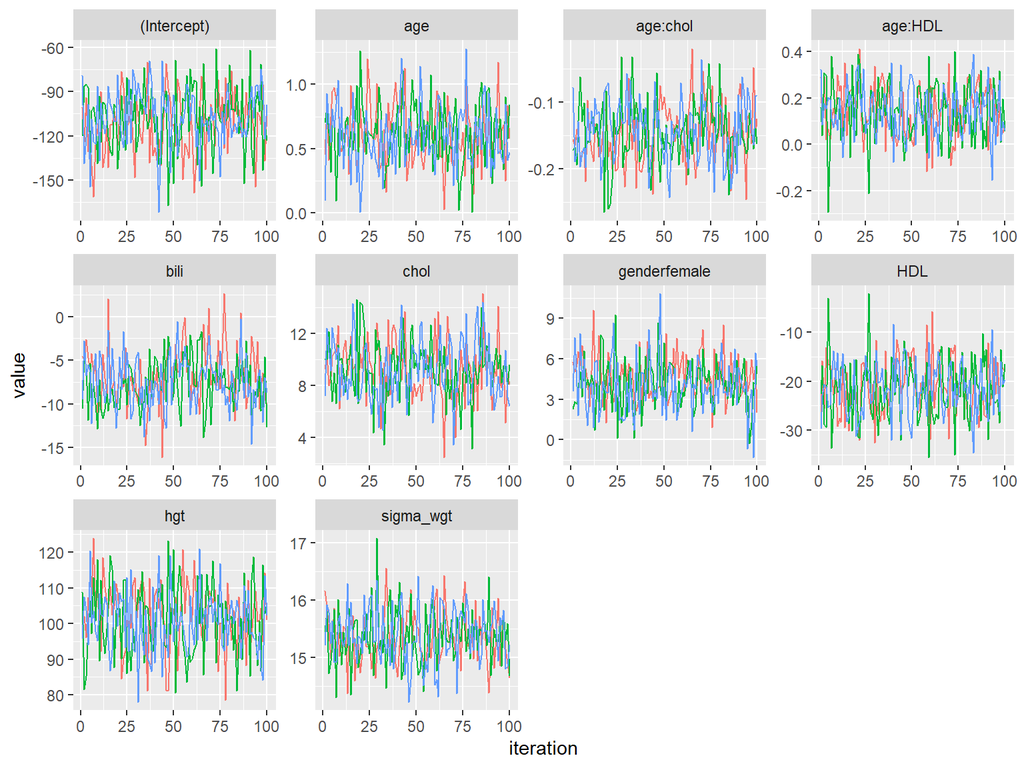

```r
traceplot(lm2, use_ggplot = TRUE, ncol = 4) +
  theme(legend.position = 'none')
```

Note:

In the recent update of R to version 4.0.0, several things changed. These changes also affect the function `traceplot()` of **JointAI** when the (default) `matplot()` is use instead of the `use_ggplot = TRUE` option.

Currently, the standard output (when `use_ggplot = TRUE` is not used) does not work properly. This will be fixed in the next version of **JointAI**.

#### Task 2

Investigate convergence of `lm2` using the Gelman-Rubin criterion, implemented in the function `GR_crit()`.

The upper limit of the confidence interval (“`Upper C.I.`”) should not be much larger than 1.

#### Solution 2

```r
GR_crit(lm2)
```

```
## Potential scale reduction factors:
##
##              Point est. Upper C.I.
## (Intercept)       1.011      1.044
## genderfemale      1.030      1.107
## bili              1.026      1.089
## age               0.998      1.005
## chol              0.996      0.997
## HDL               1.001      1.003
## hgt               1.009      1.031
## age:chol          0.997      1.001
## age:HDL           1.002      1.004
## sigma_wgt         1.000      1.006
##
## Multivariate psrf
##
## 1.08
```

#### Continue

When we are satisfied with the convergence of the MCMC chains we can take a look at the MCMC sample is precise enough. We can do this by comparing the Monte Carlo error (which describes the error made since we have just a finite sample) to the estimated standard deviation. This is implemented in the function `MC_error()`.

#### Task 3

Calculate the Monte Carlo error for `lm2`.

#### Solution 3

```r
MC_error(lm2)
```

```
##                  est   MCSE     SD MCSE/SD
## (Intercept)  -109.08 1.1752 20.356   0.058
## genderfemale    4.24 0.1077  1.865   0.058
## bili           -7.32 0.2686  3.056   0.088
## age             0.62 0.0139  0.241   0.058
## chol            9.25 0.1309  2.267   0.058
## HDL           -21.43 0.3382  5.859   0.058
## hgt           101.21 0.5310  9.197   0.058
## age:chol       -0.14 0.0027  0.045   0.059
## age:HDL         0.14 0.0068  0.118   0.058
## sigma_wgt      15.37 0.0218  0.466   0.047
```

The output shows us the posterior mean (`est`), and standard deviaiton `SD`, as well as the Monte Carlo error (`MCSE`) and the ratio of the Monte Carlo error to the posterior standard deviation (`MCSE/SD`).

This ratio should not bee too large. A rule of thumb is that it should be less than 5%.

To get a quick overview of this ratio we can also plot it:

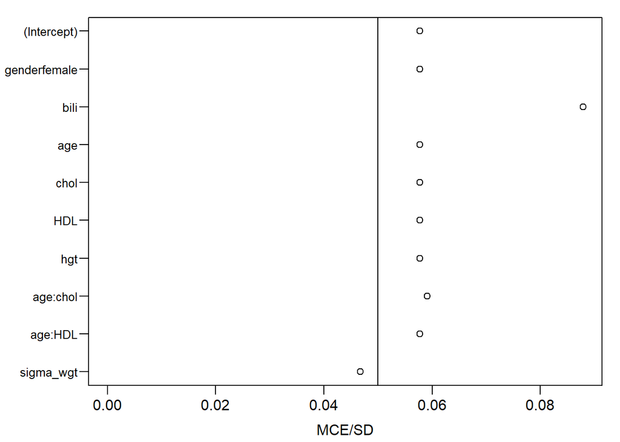

```r
par(mar = c(3.2, 5, 1, 1), mgp = c(2, 0.6, 0))
plot(MC_error(lm2))
```

### Results

#### Task

Get the summary of the model using the function `summary()`.

#### Solution

```r
summary(lm2)
```

```
##
##  Linear model fitted with JointAI
##
## Call:
## lm_imp(formula = wgt ~ gender + bili + age * (chol + HDL) + hgt,
##     data = EP16dat2, n.iter = 100, auxvars = ~educ + race + SBP +
##         hypten + WC, refcats = "largest", models = c(bili = "lognorm"),
##     seed = 2020)
##
## Posterior summary:
##                  Mean      SD      2.5%    97.5% tail-prob. GR-crit
## (Intercept)  -109.076 20.3557 -152.2890 -70.9956     0.0000   1.044
## genderfemale    4.236  1.8648    0.8094   8.0345     0.0200   1.107
## bili           -7.322  3.0557  -12.7109  -1.1883     0.0267   1.089
## age             0.616  0.2412    0.1732   1.0926     0.0000   1.005
## chol            9.247  2.2669    4.6426  14.1251     0.0000   0.997
## HDL           -21.426  5.8585  -31.9315 -11.4796     0.0000   1.003
## hgt           101.214  9.1968   82.5090 119.0574     0.0000   1.031
## age:chol       -0.144  0.0455   -0.2342  -0.0542     0.0000   1.001
## age:HDL         0.143  0.1182   -0.0666   0.3513     0.2000   1.004
##
## Posterior summary of residual std. deviation:
##           Mean    SD 2.5% 97.5% GR-crit
## sigma_wgt 15.4 0.466 14.4  16.3    1.01
##
##
## MCMC settings:
## Iterations = 101:200
## Sample size per chain = 100
## Thinning interval = 1
## Number of chains = 3
##
## Number of observations: 500
```

## Additional exercise JointAI

### Monitoring imputed values

**JointAI** also allows us to extract imputed values to generate multiple imputed datasets that can, for instance, be used for a secondary analysis.

To be able to extract the imputed values, it is necessary to specify in advance that these values should be monitored (“recorded”). This can be done using the argument `monitor_params`.

`monitor_params` uses a number of key words to specify which (groups of) parameters or values should be monitored. Each key word works like a switch and can be set to `TRUE` or `FALSE`. For more details see the vignette on [Parameter Selection](https://nerler.github.io/JointAI/articles/SelectingParameters.html).

For monitoring imputed values, `monitor_params = c(imps = TRUE)` needs to be specified.

#### Task

Re-fit the linear regression model, but now additionally set the argument `monitor_params` to keep the imputed values.

#### Solution

```r
lm3 <- lm_imp(wgt ~ gender + bili + age * (chol + HDL) + hgt, data = EP16dat2,
               auxvars = ~ educ + race + SBP + hypten + WC,
               models = c(bili = 'lognorm'), refcats = 'largest',
               n.iter = 250, monitor_params = c(imps = TRUE), seed = 2020)
```

### Extracting imputed data

The function `get_MIdat()` allows us to create multiple completed datasets from an object of class `JointAI`.

It takes the following arguments

| `object` | an object of class `JointAI` |
| --- | --- |
| `m` | number of imputed datasets |
| `include` | should the original, incomplete data be included? (default is `TRUE`) |
| `start` | first iteration of interest; allows discarding burn-in iterations |
| `minspace` | minimum number of iterations between iterations chosen as imputed values (default is 50) |
| `seed` | optional seed value |
| `export_to_SPSS` | logical; should the completed data be exported to SPSS? |
| `resdir` | optional directory for results (for export to SPSS) |
| `filename` | optional file name (for export to SPSS) |

#### Task 1

- Extract 10 imputed datasets from `lm3`.
- Inspect the resulting object.

#### Solution 1

```r
MIdat3 <- get_MIdat(lm3, m = 10)

head(MIdat3)
```

```
##      Imputation_     wgt gender bili age chol  HDL    hgt                 educ               race
## 597            0  78.018   male  1.1  67 6.13 1.09 1.7526     College or above              other
## 159            0  78.018   male  0.7  39 4.65 1.14 1.7780 High school graduate Non-Hispanic White
## 2121           0  75.296 female  0.5  64 4.14 1.29 1.6256     College or above              other
## 2549           0  90.718   male  0.8  36 3.47 1.37 1.9304         some college Non-Hispanic White
## 1172           0 112.037 female  0.6  33 6.31 1.27 1.7272         some college Non-Hispanic Black
## 1199           0  58.967   male  0.7  62 4.47 0.85 1.6002 High school graduate              other
##         SBP hypten    WC agechol ageHDL .rownr .id
## 597  138.67    yes  91.6  410.71  73.03      1   1
## 159  102.67     no  84.5  181.35  44.46      2   2
## 2121    NaN    yes  91.6  264.96  82.56      3   3
## 2549 115.33    yes  95.4  124.92  49.32      4   4
## 1172 106.67     no 119.6  208.23  41.91      5   5
## 1199 140.67    yes  89.0  277.14  52.70      6   6
```

We see that some columns were added to the data:

- `Imputation_` identifies the imputation number
- `.id` is the subject ID
- `.rownr` refers to the row number of the original data

```r
summary(MIdat3)
```

```
##   Imputation_      wgt           gender          bili            age          chol
##  Min.   : 0   Min.   : 39.0   male  :2772   Min.   :0.200   Min.   :20   Min.   : 1.91
##  1st Qu.: 2   1st Qu.: 65.2   female:2728   1st Qu.:0.600   1st Qu.:31   1st Qu.: 4.27
##  Median : 5   Median : 76.2                 Median :0.700   Median :43   Median : 4.89
##  Mean   : 5   Mean   : 78.3                 Mean   :0.742   Mean   :45   Mean   : 5.01
##  3rd Qu.: 8   3rd Qu.: 86.4                 3rd Qu.:0.900   3rd Qu.:58   3rd Qu.: 5.65
##  Max.   :10   Max.   :167.4                 Max.   :2.900   Max.   :79   Max.   :10.68
##                                             NA's   :47                   NA's   :41
##       HDL            hgt                         educ                      race
##  Min.   :0.36   Min.   :1.40   Less than 9th grade : 345   Mexican American  : 572
##  1st Qu.:1.14   1st Qu.:1.63   9-11th grade        : 759   Other Hispanic    : 638
##  Median :1.34   Median :1.68   High school graduate:1266   Non-Hispanic White:2002
##  Mean   :1.40   Mean   :1.69   some college        :1630   Non-Hispanic Black:1232
##  3rd Qu.:1.60   3rd Qu.:1.75   College or above    :1499   other             :1056
##  Max.   :3.13   Max.   :1.93   NA's                :   1
##  NA's   :41     NA's   :11
##       SBP         hypten           WC           agechol          ageHDL           .rownr
##  Min.   : 74.6   no  :4066   Min.   : 56.7   Min.   : 45.5   Min.   :  7.92   Min.   :  1
##  1st Qu.:109.3   yes :1413   1st Qu.: 85.0   1st Qu.:140.2   1st Qu.: 39.37   1st Qu.:126
##  Median :118.7   NA's:  21   Median : 95.4   Median :222.3   Median : 57.40   Median :250
##  Mean   :120.3               Mean   : 96.3   Mean   :227.7   Mean   : 63.14   Mean   :250
##  3rd Qu.:129.2               3rd Qu.:105.1   3rd Qu.:296.4   3rd Qu.: 80.04   3rd Qu.:375
##  Max.   :202.0               Max.   :156.8   Max.   :725.9   Max.   :171.36   Max.   :500
##  NA's   :29                  NA's   :23      NA's   :451     NA's   :451
##       .id
##  Min.   :  1
##  1st Qu.:126
##  Median :250
##  Mean   :250
##  3rd Qu.:375
##  Max.   :500
##
```

#### Task 2

Similar to the functions `densplot()` from the **mice** package and `propplot()`, the function `plot_imp_distr()` from **JointAI** allows us to plot the distribution of the observed and imputed values for the incomplete variables.

It takes the following arguments

| `data` | a data.frame in long format containing multiple imputations (and the original incomplete data) |
| --- | --- |
| `imp` | the name of the variable specifying the imputation indicator |
| `id` | the name of the variable specifying the subject indicator |
| `rownr` | the name of a variable identifying which rows correspond to the same observation in the original (unimputed) data |
| `ncol`, `nrow` | optional number of rows and columns in the plot layout; automatically chosen if unspecified |

Check the imputed values in `MIdat3` using `plot_imp_distr()`.

#### Solution 2

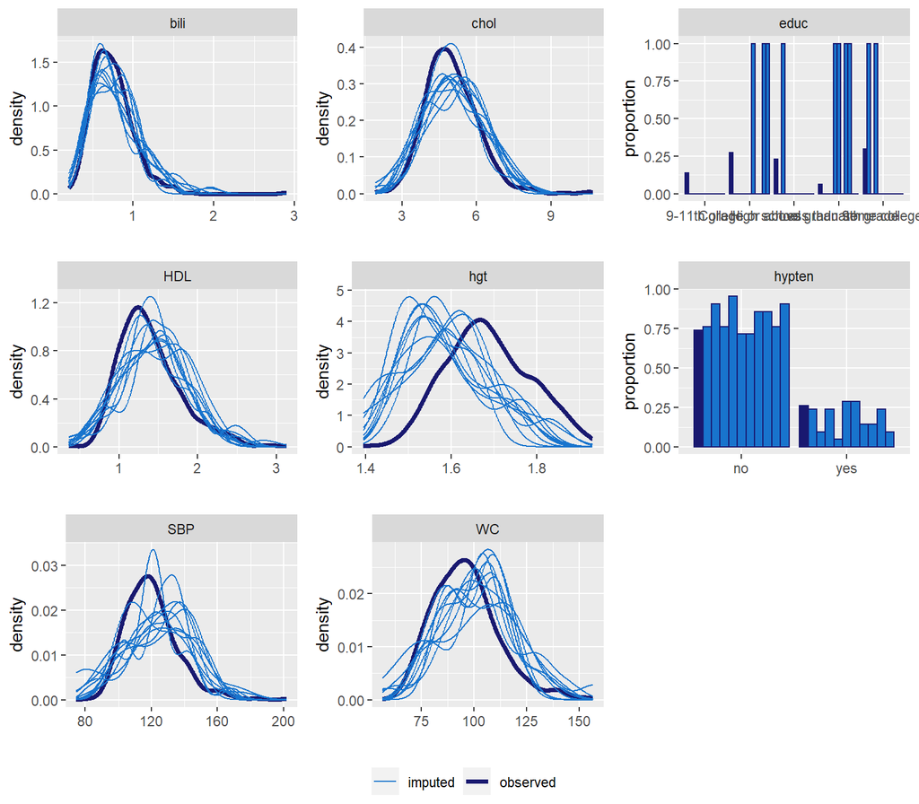

```r
plot_imp_distr(MIdat3)
```

### Transforming imputed data to a mids object

To perform standard analyses on the imputed data it is usefull to convert them to a `mids` object, so that they can be treated as if they had been imputed with `mice()`.

The **mice** package proves the function `as.mids()` to convert a long-format dataset (with original and multiple imputed datasets stacked onto each other) to a `mids` object.

#### Task

Transform `MIdat3` to a `mids` object and confirm that it has worked by checking the `class` of the result.

#### Solution

```r
mids3 <- mice::as.mids(MIdat3, .imp = "Imputation_", .id = '.id')

class(mids3)
```

```
## [1] "mids"
```

© Nicole Erler